# STOR 538 Final Project Visuals-Gavin Rowland

Gavin Rowland

2025-11-30

# Load/Clean Data

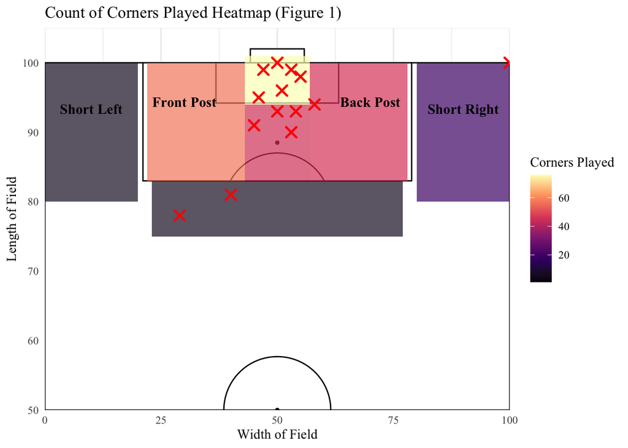

```r
corners2 <- corners %>%
  mutate(new_location = ifelse(corners$Location == "Short" & corners$Left.Side == 1, "Short Left", ifelse(corners$Location == "Short" & corners$Left.Side == 0, "Short Right", Location)))

goal_locations <- data.frame(
  x = c(93, 91, 94, 99, 99, 100, 81, 95, 98, 90, 78, 93, 100, 96),
  y = c(50, 45, 58, 53, 47, 100, 40, 46, 55, 53, 29, 54, 50, 51)
)

zones <- data.frame(
  zone = c("Short Left", "Penalty Spot", "Back Post", "Goalmouth",
           "Front Post", "Other", "Top of Box", "Short Right"),
  xmin = c(80, 83, 83, 94, 83, 0, 75, 80),
  xmax = c(100, 94, 100, 101, 100, 0, 83, 100),
  ymin = c(0, 43, 57, 43, 22, 0, 23, 80),
  ymax = c(20, 57, 78, 57, 43, 0, 77, 100)
)

location_count_corners <- corners2 %>%
  count(new_location) %>%
  rename(zone = new_location)

data_w_zonecount <- zones %>%
  left_join(location_count_corners, by = "zone")


plot1 <- ggplot(data_w_zonecount) +
  annotate_pitch(colour = "black", fill = "white") +
  geom_rect(aes(xmin = xmin, xmax = xmax, ymin = ymin, ymax = ymax,
                fill = n), alpha = 0.7) +
  geom_point(data = goal_locations, aes(x, y),
             shape = 4, size = 3, stroke = 1.3, color = "red")+
  coord_flip(xlim = c(50,105), ylim = c(0,100), expand = FALSE) +
  scale_fill_viridis_c(option = "magma", name = "Corners Played") +
  labs(title = "Count of Corners Played Heatmap (Figure 1)",
       x = "Length of Field",
       y = "Width of Field",
       family = "Times New Roman")+
  geom_text(data = data.frame(x = c(90, 91, 91, 90),
                              y = c(10, 30, 70, 90),
                              label = c("Short Left", "Front Post", "Back Post", "Short Right")),
            vjust = -2, size = 4, family = "Times New Roman", fontface = "bold",aes(x, y, label = label))+
  theme_minimal(base_family = "Times New Roman")

plot1
```

This heat map (Figure 1) was created to illustrate the count of corners played into each location on the field as well as the locations of players for each goal recorded. Each zone represents an area of the field recorded in our “Location” variable. Short passes were split based on whether they occurred on the right or left side of the field. In this figure, the left side of the field and front post are represented on the left half while the right side of the field and back post are represented on the right half. It’s important to note that we did not split front and back post by side of the field and the counts you see are the totals for front/back post, not counting the side of the field they were on. Each red X-mark represents the location of a goalscorer from where he kicked the ball into the goal. For example, one goal was scored from the corner kick itself thus, the X-mark is in the corner from which he scored.

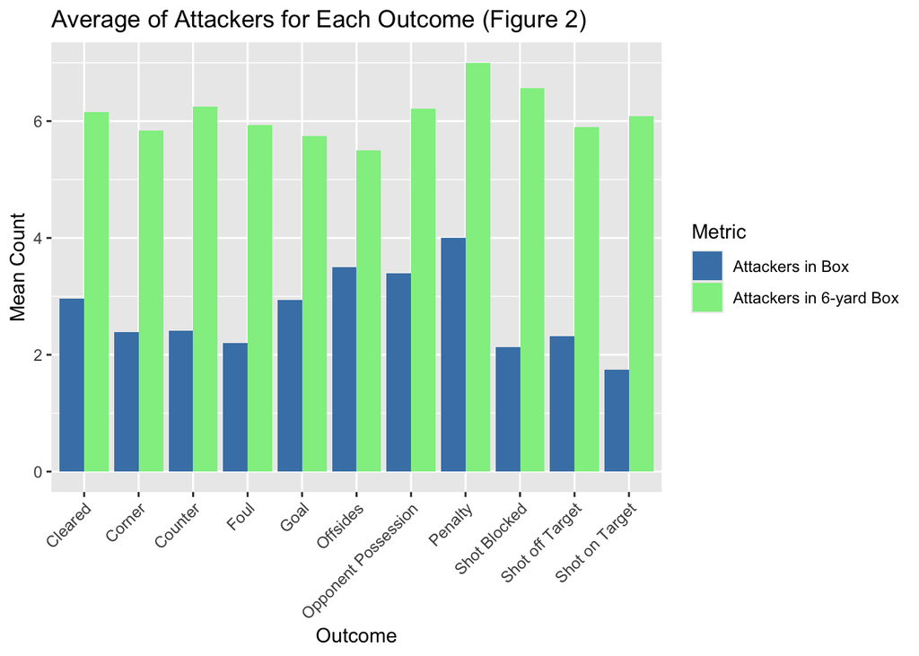

This bar plot(Figure 2) was created to display the average amount of attackers in the box (A.in.Box) and in the 6-yard box (A.in.6) for each different outcome. Each outcome has two bars, the blue bar, representing the mean count of attackers in the box for each possible outcome, and the green bar, representing the mean count of attackers in the 6-yard box.

```r
freq_table <- corners %>%
  count(Location, Outcome) %>%
  pivot_wider(names_from = Outcome,
              values_from = n,
              values_fill = 0)

freq_table
```

```
## # A tibble: 7 × 12
##   Location     Cleared Corner Counter  Foul  Goal `Opponent Possession` Penalty
##   <chr>          <int>  <int>   <int> <int> <int>                 <int>   <int>
## 1 Back Post         15      4       3     1     3                     9       1
## 2 Front Post        33      4       3     3     0                     5       0
## 3 Goalmouth         24      3       3     7     6                    13       0
## 4 Other              0      0       0     0     0                     1       0
## 5 Penalty Spot      16      4       3     3     1                     6       0
## 6 Short              4      2       0     1     5                     4       0
## 7 Top of Box         2      1       0     0     1                     0       0
## # ℹ 4 more variables: `Shot Blocked` <int>, `Shot off Target` <int>,
## #   `Shot on Target` <int>, Offsides <int>
```

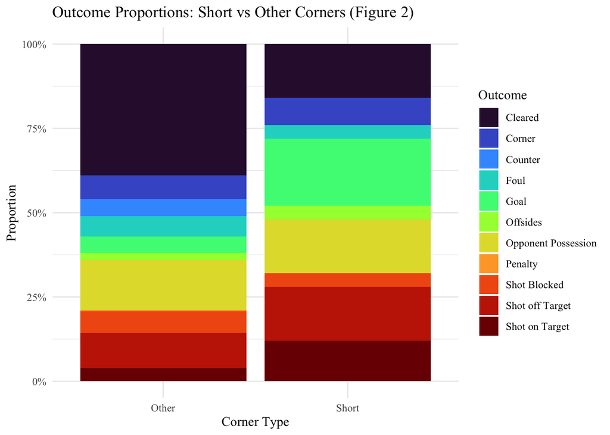

```r
df_prop <- corners %>%
  mutate(LocationGroup = ifelse(Location == "Short", "Short", "Other")) %>%
  count(LocationGroup, Outcome) %>%
  group_by(LocationGroup) %>%
  mutate(prop = n / sum(n))

ggplot(df_prop, aes(x = LocationGroup, y = prop, fill = Outcome)) +
  geom_col() +
  labs(title = "Outcome Proportions: Short vs Other Corners (Figure 2)",
       x = "Corner Type",
       y = "Proportion",) +
  scale_fill_viridis_d(option = "turbo", name = "Outcome")+
  scale_y_continuous(labels = scales::percent) +
  theme_minimal(base_family = "Times New Roman")
```

Figure 2 is a stacked bar chart illustrating the difference in proportions of outcomes for short corners compared to all other locations of corners. Each color of the bar represents the proportion of a specific outcome.

```r
df_prop
```

```
## # A tibble: 20 × 4
## # Groups:   LocationGroup [2]
##    LocationGroup Outcome                 n    prop
##    <chr>         <chr>               <int>   <dbl>
##  1 Other         Cleared                90 0.390
##  2 Other         Corner                 16 0.0693
##  3 Other         Counter                12 0.0519
##  4 Other         Foul                   14 0.0606
##  5 Other         Goal                   11 0.0476
##  6 Other         Offsides                5 0.0216
##  7 Other         Opponent Possession    34 0.147
##  8 Other         Penalty                 1 0.00433
##  9 Other         Shot Blocked           15 0.0649
## 10 Other         Shot off Target        24 0.104
## 11 Other         Shot on Target          9 0.0390
## 12 Short         Cleared                 4 0.16
## 13 Short         Corner                  2 0.08
## 14 Short         Foul                    1 0.04
## 15 Short         Goal                    5 0.2
## 16 Short         Offsides                1 0.04
## 17 Short         Opponent Possession     4 0.16
## 18 Short         Shot Blocked            1 0.04
## 19 Short         Shot off Target         4 0.16
## 20 Short         Shot on Target          3 0.12
```

```r
write_csv(df_prop, "ShortVsOtherProps.csv")
```

Figure 2 showed some interesting proportions comparing short corners to all other corners. For example, 12% of short corners led to a shot on target while only 4% of all other corners led to shots on target. This led us to wonder whether or not short corners were more dangerous than the others.